# Beiler et al. 2015

## Exploring Pandora, right here at home

The Na’vi of Pandora know something of how their world works, and we are working hard to understand ours. Our world is a highly antagonistic world, driven by consumption - a tangled bank, nature, red in tooth and claw. However, all around us and hidden beneath our feet, many species cooperate to survive and thrive in this otherwise harsh world. This cooperation can happen among species and it can also happen among individuals within a species. Suzanne Simard and others have been investigating belowground networks of nutrient flux and information sharing among individuals and between species.

Most plant species develop mycorrhizae, fungi-root associations which are typically mutualistic interactions. These fungi can often connect individuals of the same species together, creating a network by which one plant can information, nutrients, and carbon with another plant via this fungal highway. However, how these connections are structured is still very poorly known. In an effort to shed some light on this, @Beiler2015 described the topology of Douglas fir trees connected by two species of individual fungal genets, in contrast environments.

### Properties assessed

1. Application of networks to mycorrhizae
- node = tree
- link = one or more fungal genets connecting two trees
- triplet = three connected trees (open triplet is connected by two links, closed, by three)
1. Network properties
- link density (links/species)
- degree distribution (statistical distribution of node degrees)
- global or network clustering coefficient: fraction of triplets that are closed (no. of closed triplets) / (no. of open + no. closed triplets)
- mean lcoal clustering coefficient among nodes in each network
- Betweenness centrality: the number of times a node acts as a bridge along the shortest path between two other nodes. How important is this node in making connections for other nodes?
- Evaluated by testing whether the observed differ from random networks (Erdos-Renyi models) based on the same number of nodes and average node degree as empirical MNs.
2. Node properties
- degree (# of links)
- normalized degree: (fraction: d / all possible d)
- node clustering coefficient (local transivity; extent to which its neighbors are are connected) C. “Network classifications were verified by contrasting empirical networks against undirected random Erdos-Renyi configurations … having the same number of nodes and mean node degree as the empirical networks, when pairs of nodes are linked at random.”

## Results

- Vesiculosus more structured than vinicolor
- Vinicolor nested within vesiculosus

No significant relations found between site (soil moisture) and network properties

- network density
- mean node degree, or
- network clustering coefficient

However, node clustering coefficient and node degree increased with tree dbh (Fig. 4). Seems strange then, that there is a negative relation between node clustering coef and node degree.

## Data from Beiler et al.

Plot 1

- 26 trees, 258 links (Table 1), node clustering coefficient: 0.84

```r
# for Plot 1
V <- 26
E <- 258

gr <- erdos.renyi.game(V, E, type = "gnm")
# graph "order" and "size"
gorder(gr); gsize(gr)
```

```
## [1] 26
```

```
## [1] 258
```

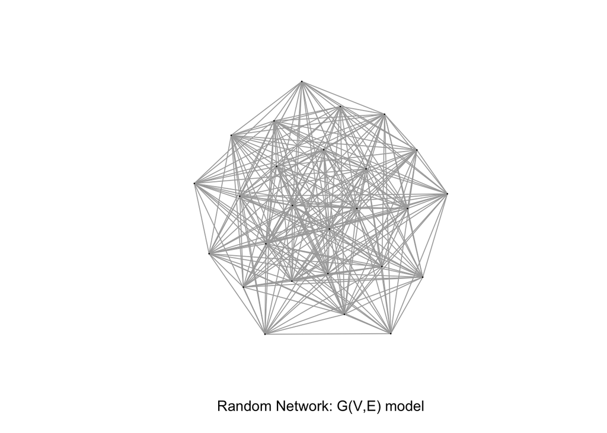

```r
plot(gr, vertex.label= NA, edge.arrow.size=0.02,vertex.size = 0.5, xlab = "Random Network: G(V,E) model")
```

```r
# betweenness centrality
bc <- betweenness(gr, v = V(gr), directed = TRUE, weights = NULL,
  nobigint = TRUE, normalized = FALSE)
bcbar <- mean(bc)

# node clustering coefficients (per node)
ncc <- transitivity(gr, type = "local")
# mean node clustering coefficient
mean(ncc) # cf 0.84
```

```
## [1] 0.7951004
```

```r
# degrees of each node
d <- degree(gr)
# mean degree
mean(d) # cf 18
```

```
## [1] 19.84615
```

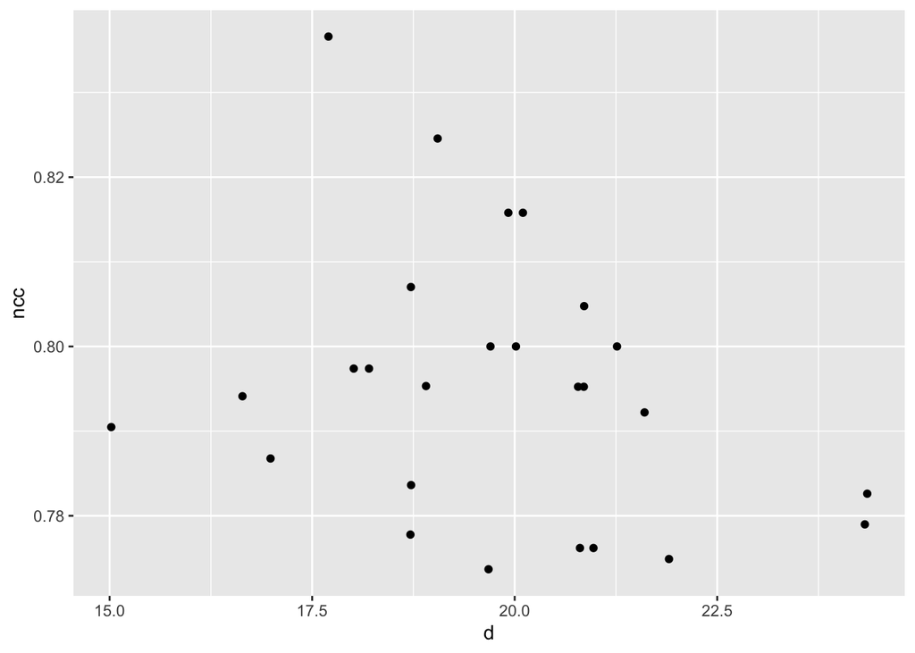

```r
qplot(d, ncc, geom="jitter")
```

### for all plots

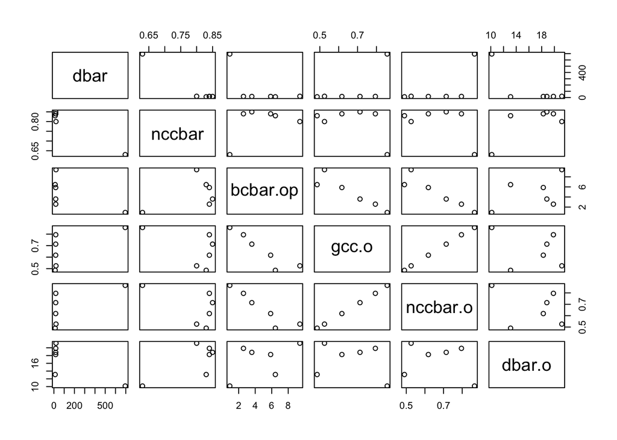

```r
V <- c(26, 13, 31, 27, 27, 41)
E <- c(258, 66, 283, 254, 177, 434)
pV <- c(.846, .5, .875, .846, .778, .889)
dbar <- c(18, 695, 17.15, 17.52, 12.21, 20.19)
nccbar <- c(.84, .63, .84, .85, .83, .8)
plot <- 1:6
df <- data.frame(plot=plot, V=V, E=E, pV=pV, dbar=dbar, nccbar=nccbar)

myStats <- function(ve){
  # ve is a vector of V, E
  V <- ve[1];  E <- ve[2]
  gr <- erdos.renyi.game(V, E, type = "gnm")

  bc <- betweenness(gr, directed = FALSE, weights = NULL,
  nobigint = TRUE, normalized = FALSE)
  bcbar <- mean(bc)

  #Network clustering coefficient
  gcc <- transitivity(gr)

  ncc <- transitivity(gr, type = "local")
# mean node clustering coefficient
 nccbar.o <- mean(ncc) # cf 0.84
# degrees of each node
d <- degree(gr)
# mean degree
dbar.o <- mean(d) # cf 18
return( c(bcbar.op=bcbar, gcc.o=gcc, nccbar.o=nccbar.o, dbar.o=dbar.o))
}
df2 <- cbind(df, t(apply(df[,2:3], 1, myStats)) )
pairs(df2[,5:10])
```

## Fig. 2 but with random graphs

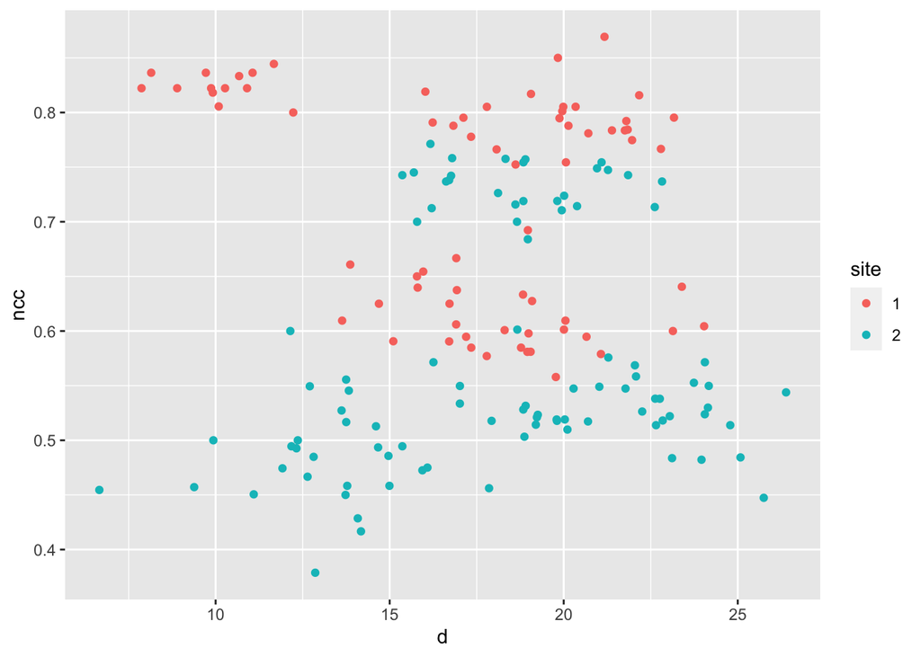

```r
ncc1 <- unlist( apply(df[1:3,2:3], 1, function(ve){
   gr <- erdos.renyi.game(ve[1], ve[2], type = "gnm")
   transitivity(gr, type = "local")
 }))
ncc2 <- unlist( apply(df[4:6,2:3], 1, function(ve){
   gr <- erdos.renyi.game(ve[1], ve[2], type = "gnm")
   transitivity(gr, type = "local")
 }))

d1 <- unlist( apply(df[1:3,2:3], 1, function(ve){
   gr <- erdos.renyi.game(ve[1], ve[2], type = "gnm")
   degree(gr)
 }))
d2 <- unlist( apply(df[4:6,2:3], 1, function(ve){
   gr <- erdos.renyi.game(ve[1], ve[2], type = "gnm")
   degree(gr)
 }))
dff2 <- data.frame(site = factor(c(rep(1, length(ncc1)), rep(2, length(ncc2)))),
                            ncc =c(ncc1, ncc2), d=c(d1,d2) )
ggplot(dff2, aes(d, ncc, colour=site) ) + geom_jitter()
```

## Fig. 2 but with scale-free graphs

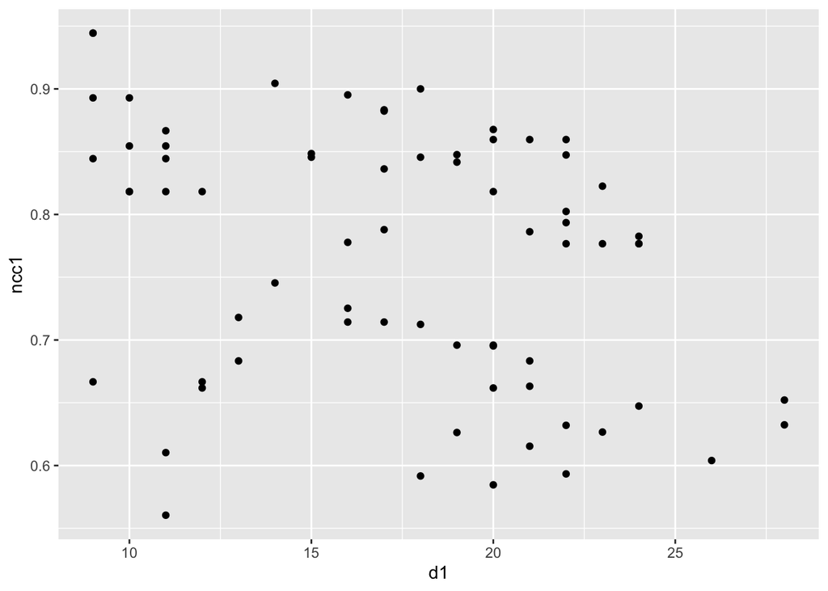

```r
exp.out <- 2.1
ncc1 <- unlist( apply(df[1:3,2:3], 1, function(ve){
  gsf <- sample_fitness_pl(ve[1], ve[2], exponent.out= exp.out, exponent.in = -1, loops = FALSE, multiple = FALSE, finite.size.correction = TRUE)
   transitivity(gsf, type = "local")
 }))
ncc2 <- unlist( apply(df[4:6,2:3], 1, function(ve){
  gsf <- sample_fitness_pl(ve[1], ve[2], exponent.out= exp.out, exponent.in = -1, loops = FALSE, multiple = FALSE, finite.size.correction = TRUE)
   transitivity(gsf, type = "local")
 }))

d1 <- unlist( apply(df[1:3,2:3], 1, function(ve){
  gsf <- sample_fitness_pl(ve[1], ve[2], exponent.out= exp.out, exponent.in = -1, loops = FALSE, multiple = FALSE, finite.size.correction = TRUE)
   degree(gsf)
 }))
qplot(d1, ncc1)
```

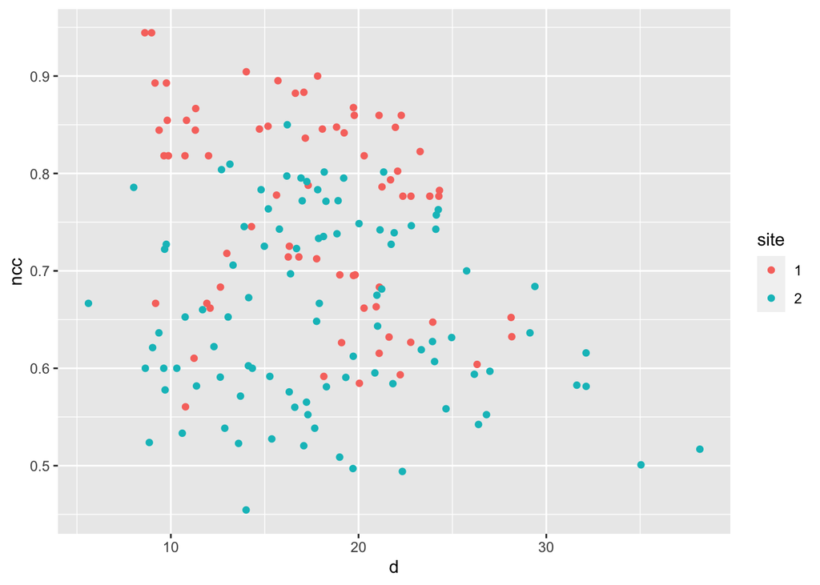

```r
d2 <- unlist( apply(df[4:6,2:3], 1, function(ve){
   gsf <- sample_fitness_pl(ve[1], ve[2], exponent.out= exp.out, exponent.in = -1, loops = FALSE, multiple = FALSE, finite.size.correction = TRUE)
   degree(gsf)
 }))
dff2 <- data.frame(site = factor(c(rep(1, length(ncc1)), rep(2, length(ncc2)))),
                            ncc =c(ncc1, ncc2), d=c(d1,d2) )
ggplot(dff2, aes(d, ncc, colour=site) ) + geom_jitter()
```

## Fig. 2 but with small-world

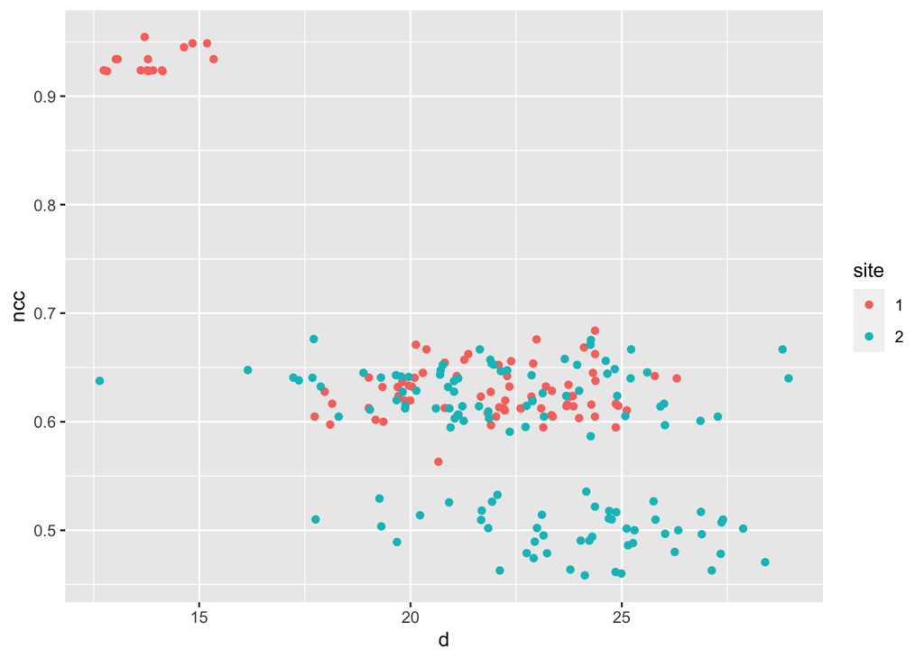

```r
dm=2
nei=3
p=.2
{
ncc1 <- unlist( apply(df[1:3,2:3], 1, function(ve){
  size <- ceiling((ve[1])^(1/dm))
  gsw <- sample_smallworld(dim=2, size, nei , p )
   transitivity(gsw, type = "local")
 }))
ncc2 <- unlist( apply(df[4:6,2:3], 1, function(ve){
    size <- ceiling((ve[1])^(1/dm))
  gsw <- sample_smallworld(dim=2, size, nei, p)
   transitivity(gsw, type = "local")
 }))

d1 <- unlist( apply(df[1:3,2:3], 1, function(ve){
   size <- ceiling((ve[1])^(1/dm))
  gsw <- sample_smallworld(dim=2, size, nei, p)
   degree(gsw)
 }))
qplot(d1, ncc1)
d2 <- unlist( apply(df[4:6,2:3], 1, function(ve){
      size <- ceiling((ve[1])^(1/dm))
  gsw <- sample_smallworld(dim=2, size, nei, p)
   degree(gsw)
 }))
dff2 <- data.frame(site = factor(c(rep(1, length(ncc1)), rep(2, length(ncc2)))),
                            ncc =c(ncc1, ncc2), d=c(d1,d2) )
ggplot(dff2, aes(d, ncc, colour=site) ) + geom_jitter()
}
```